# ECGR

## Overview

ECGR is a package to process and analyze Electrocardiogram (ECG) with the R language. This package (up to now) provides a simple way for filter signal and identify/visualize R waves, calculate heart rate and some parameters from the time domain of Heart Rate Variability (HRV).

## Instalation

`devtools::install_github('clauciorank/ECGR')`

## Usage

#### Here I’ll a propose a step by step method that should be enough for R peak identification in a raw signal ECG obtained from [PhysioNet ECG-ID Database](https://physionet.org/content/ecgiddb/1.0.0/). The package comes with 2 examples pre-loaded: **ECGexample1** and **ECGexample2**.

1.Load data - The package proposal is simplify the cardiac electric signal processing with R so we will use some of the simplest data structures in R. (Yay!!).

`data <- ECGR::ECGexample1`

2. Visualize ECG.

`plot(data$raw_signal, type = 'l')`

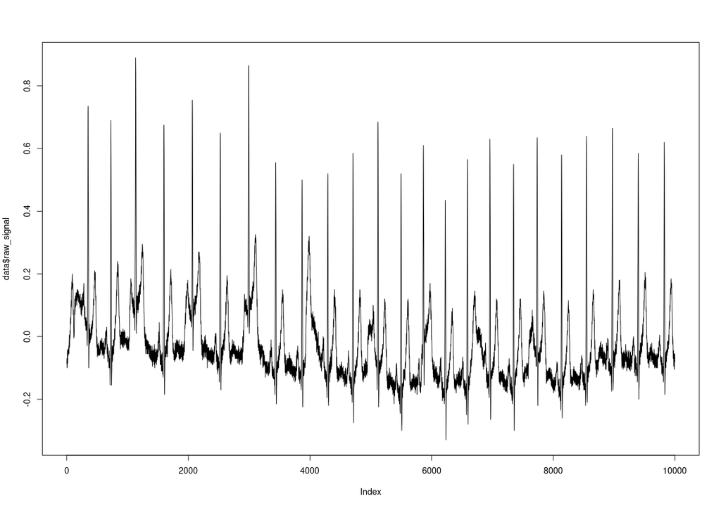

plot

3.Signal filtering with butterfilter (optional but strongly recommended).

`data$filtered <- ECGR::ecg_filter(data$raw_signal, sample_rate = 500, butter_low = 5, butter_high = 80)`

Plot to see the the difference!

`plot(data$filtered, type = 'l')`

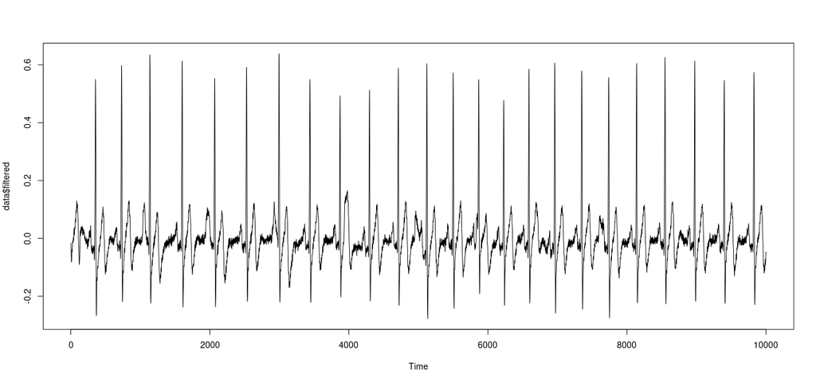

plot2

4.R peak indexes identification (threshold (y) should be adjusted to a number that include the R peaks).

`peaks <- ECGR::find_r_peaks(data$filtered, sample_rate = 500, FCmax = 220, threshold = .2)`

5.Visualize the identified R peaks

`plot_r_peaks(data$filtered, peaks)`

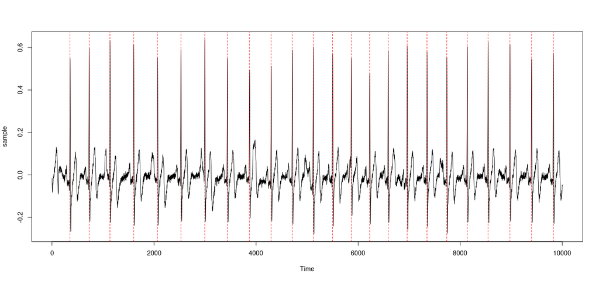

plot3

6.Mean Heart rate

`ECGR::mean_heart_rate(sample = data$filtered, Rpeaks = peaks)`

`[1] 72.83859`

7.HRV parameters